# Data science of climate change

#### Project by Gloria BENOIT, supervised by Pierre Poulain in Programmation Python 2 (BQAAY080, M1BI, 2023)

This project aims to quantify and characterize climate change, by finding data sources and reproducing scientific graphs. The project is being carried out in two stages: analysis of atmospheric CO2, followed by analysis of temperature trends.

## Atmospheric CO2

### Data source

#### National Oceanic and Atmospheric Administration (NOAA)

[NOAA](https://www.noaa.gov/about-our-agency) is an agency of the U.S. department of commerce that “enriches life through science”. They work to keep the public informed of the changing environment around them. In 1972, they've created [The Global Monitoring Laboratory](https://gml.noaa.gov/) (GML), as part of the NOAA Environmental Research Laboratories. It's mission is focused on geophysical monitoring for climatic change.

GML conducts research that addresses three major challenges: greenhouse gas and carbon cycle feedbacks, changes in clouds, aerosols, and surface radiation, and recovery of stratospheric ozone. One of four programs created by GML is the [Carbon Cycle Greenhouse Gases](https://gml.noaa.gov/ccgg/) (CCGG), in which the spatial and temporal distributions of greenhouse gases are measured and modeled.

The CCGG research area operates the [Global Greenhouse Gas Reference Network](https://gml.noaa.gov/ccgg/ggrn.php), measuring the atmospheric distribution and trends of the three main long-term drivers of climate change, carbon dioxide (CO2), methane (CH4), and nitrous oxide (N2O), as well as carbon monoxide (CO) which is an important indicator of air pollution.

#### CO2 measurements in the 70s

NOAA Carbon Dioxide (CO2) measurements first began in 1967 at the Niwot Ridge high altitude research station, Colorado. Since then, the CCGG cooperative air sampling network measures CO2 from more than 50 sites world wide. In-Situ continuous measurements of CO2 at the NOAA GML Atmospheric Baseline Observatories began in 1973. Additional in-situ measurements from tall towers and light aircraft in the USA began in the 1990's, to support studies on continental sources and sinks of greenhouse gases. Vertical profile data from the [AirCore Sampling System](https://gml.noaa.gov/ccgg/data/co2.html) began in 2012 to monitor greenhouse gases at high altitudes and to help evaluate remote sensing measurements.

##### Flask (1968-2022)

GML measures greenhouse gases through a cooperative air sampling network effort which began in 1967. Air samples are collected approximately weekly with flasks from a globally distributed network of sites, ranging from being collected by volunteers to being collected by aircrafts.  
Measurement data are used to identify long-term trends, seasonal variability, and spatial distribution of carbon cycle gases.

This data can be found in [GML's CO2 database](https://gml.noaa.gov/aftp/data/trace_gases/co2/flask/surface/).

##### In situ (1973-2022)

Greenhouse gases are also measured at four Atmospheric Baseline Observatories and multiple tall towers in the United States. It first began measurements of CO2 at the observatories in 1973. Continuous in-situ measurements of these gases provides great detail in their long term trends, seasonal and short-term variations, and diurnal cycles.

This data can also be found in [GML's CO2 database](https://gml.noaa.gov/aftp/data/trace_gases/co2/in-situ/surface/).

#### CO2 estimates before real measurements, paleoclimatology

The most direct method of investigating past variations of the atmospheric CO2 concentration before 1958, when continuous direct atmospheric CO2 measurements started, is the analysis of air extracted from suitable ice cores ([Siegenthaler et al., 2005](https://doi.org/10.1594/PANGAEA.728135))

The [measurement](https://www.scientificamerican.com/article/how-are-past-temperatures/) of the gas composition is direct: trapped in deep ice cores are tiny bubbles of ancient air, which we can extract and analyze using mass spectrometers.

##### From 1000 to 2004

In 2010, pre-industrial CO2 data was estimated using two ice cores. Measurements for Law Dome (LD) and Dronning Maud Land (DML) were sufficient to yield smoothed, with 50-year splines, estimates for CO2 evolution between 1000 and 2004 ([Frank et al., 2010](https://pubmed.ncbi.nlm.nih.gov/20110999/)).

This data can be found in NOAA's Paleoclimatology database, as study 10437.

##### 800,000 years before present

In 2008, two years prior, the Antarctic Vostok and EPICA Dome C ice cores had provided a composite record of atmospheric carbon dioxide levels over the past 800,000 years ([Lüthi et al., 2008](https://pubmed.ncbi.nlm.nih.gov/18480821/)).

This data can also be found in NOAA's Paleoclimatology database, as study 6091.

### Unit of measurement

When measuring gases the term *concentration* is used to describe the amount of gas by volume in the air. The two most common units of measurement are parts-per-million, and percent concentration. All of our data uses parts-per-million as their unit of measurement.  
Parts-per-million (abbreviated ppm) is the [ratio](https://www.co2meter.com/fr-fr/blogs/news/15164297-co2-gas-concentration-defined) of one gas to another. For example, 1,000 ppm of CO2 means that if you could count a million gas molecules, 1,000 of them would be of carbon dioxide and 999,000 molecules would be some other gases.

### Data analysis

```python
import matplotlib.pyplot as plt
import pandas as pd
from pathlib import Path
from urllib.request import urlretrieve
import urllib.parse
from scipy import stats
import numpy as np
```

#### In situ (1973-2022)

The dataset is stored in a text format, uses spaces as the separator and contains 20 columns for 593 lines. It contains a site code, which refers to the observatory where the data was recorded, the date, from the year down to the second, the CO2 record and other attributes of the measurements. Therefore, we have four different dataset, each specific to an observatory :

| Barrow | Mauna Loa | American Samoa | South Pole |
| --- | --- | --- | --- |
| BRW | MLO | SMO | SPO |

Their locations can be found directly on [GML's site](https://gml.noaa.gov/dv/site/?program=ccgg&active=1), where in situ observatories are marked by a blue rectangle.

```python
observatories = {"brw": "Barrow", "mlo": "Mauna Loa",
                 "smo": "American Samoa", "spo": "South Pole"}
for obs_name in observatories:
    filename = f"co2_{obs_name}_surface-insitu_1_ccgg_MonthlyData.txt"
    url = ("https://gml.noaa.gov/aftp/data/trace_gases/co2/in-situ/"
           f"surface/txt/{filename}")
    if not Path(filename).is_file():
        urlretrieve(url, filename)
```

In order to keep our dataframe legible, we will only keep the following columns : *year*, *month*, *datetime*, *time_decimal*, *value*.  
Regarding missing values, the file comments read as follows:

```
# value:_FillValue : -999.999
```

However, if we look at the minimum value for '*value*':

```python
df_mlo = pd.read_csv("co2_mlo_surface-insitu_1_ccgg_MonthlyData.txt",
                     comment='#', sep=' ', header=0)
df_mlo['value'].min()
```

```
-999.99
```

We can see how, by default, missing values are actually set as ***-999.99***.  
To prevent these values from dragging the graph down, they will be replaced by Na when we import the datasets.

```python
def read_noaa_data(filename):
    """Read a dataframe from a NOAA file correctly.

    Parameters
    ----------
    filename : string
        A dataframe in a text file from NOAA.

    Returns
    -------
    dataframe :
        The dataframe.
    """
    df = pd.read_csv(filename, comment='#', sep=' ', header=0,
                     na_values=-999.99)
    df = df[["year", "month", "datetime", "time_decimal", "value"]]
    return df
```

In order to smooth the CO2 records, we also decided to add a rolling average of eleven adjacent seasonal cycles, centered on the month to be corrected. This number was chosen to center the average value over the year, erasing the seasonal variability. At any point in time, the CO2 recorded is adjusted by the values of the nearest four-season cycle.

```python
def add_rollmean(df):
    """Add a rolling mean of 11 adjacent values to the value.

    Parameters
    ----------
    df : dataframe
        A dataframe containing a 'value' column.

    Returns
    -------
    dataframe :
        The dataframe with new 'rolling mean' column.
    """
    df["rolling_mean"] = df['value'].rolling(11, center=True).mean()
    return df
```

```python
filename = "co2_mlo_surface-insitu_1_ccgg_MonthlyData.txt"
df_noaa = read_noaa_data(filename)
df_noaa = add_rollmean(df_noaa)
df_noaa.head(15)
```

|  | year | month | datetime | time_decimal | value | rolling_mean |
| --- | --- | --- | --- | --- | --- | --- |
| 0 | 1973 | 8 | 1973-08-01T00:00:00Z | 1973.580822 | NaN | NaN |
| 1 | 1973 | 9 | 1973-09-01T00:00:00Z | 1973.665753 | NaN | NaN |
| 2 | 1973 | 10 | 1973-10-01T00:00:00Z | 1973.747945 | NaN | NaN |
| 3 | 1973 | 11 | 1973-11-01T00:00:00Z | 1973.832877 | NaN | NaN |
| 4 | 1973 | 12 | 1973-12-01T00:00:00Z | 1973.915068 | NaN | NaN |
| 5 | 1974 | 1 | 1974-01-01T00:00:00Z | 1974.000000 | NaN | NaN |
| 6 | 1974 | 2 | 1974-02-01T00:00:00Z | 1974.084932 | NaN | NaN |
| 7 | 1974 | 3 | 1974-03-01T00:00:00Z | 1974.161644 | NaN | NaN |
| 8 | 1974 | 4 | 1974-04-01T00:00:00Z | 1974.246575 | NaN | NaN |
| 9 | 1974 | 5 | 1974-05-01T00:00:00Z | 1974.328767 | 333.16 | NaN |
| 10 | 1974 | 6 | 1974-06-01T00:00:00Z | 1974.413699 | 332.17 | NaN |
| 11 | 1974 | 7 | 1974-07-01T00:00:00Z | 1974.495890 | 331.11 | NaN |
| 12 | 1974 | 8 | 1974-08-01T00:00:00Z | 1974.580822 | 329.11 | NaN |
| 13 | 1974 | 9 | 1974-09-01T00:00:00Z | 1974.665753 | 327.30 | NaN |
| 14 | 1974 | 10 | 1974-10-01T00:00:00Z | 1974.747945 | 327.30 | 330.195455 |

Seing as CO2 records only starts in may 1974, the first rolling mean is calculated in october, when none of the eleven adjacent values(month) are missing.

```python
df_noaa.describe()
```

|  | year | month | time_decimal | value | rolling_mean |
| --- | --- | --- | --- | --- | --- |
| count | 593.000000 | 593.000000 | 593.000000 | 582.000000 | 562.000000 |
| mean | 1997.789207 | 6.529511 | 1998.248087 | 369.691718 | 370.289376 |
| std | 14.278755 | 3.457692 | 14.277380 | 25.716157 | 24.883814 |
| min | 1973.000000 | 1.000000 | 1973.580822 | 327.300000 | 330.191818 |
| 25% | 1985.000000 | 4.000000 | 1985.915068 | 348.110000 | 349.289091 |
| 50% | 1998.000000 | 7.000000 | 1998.246575 | 366.815000 | 368.157273 |
| 75% | 2010.000000 | 10.000000 | 2010.580822 | 390.397500 | 390.379773 |
| max | 2022.000000 | 12.000000 | 2022.915068 | 420.970000 | 418.484545 |

With such datasets, we can observe CO2 records from 1973 up until now for all four observatories.

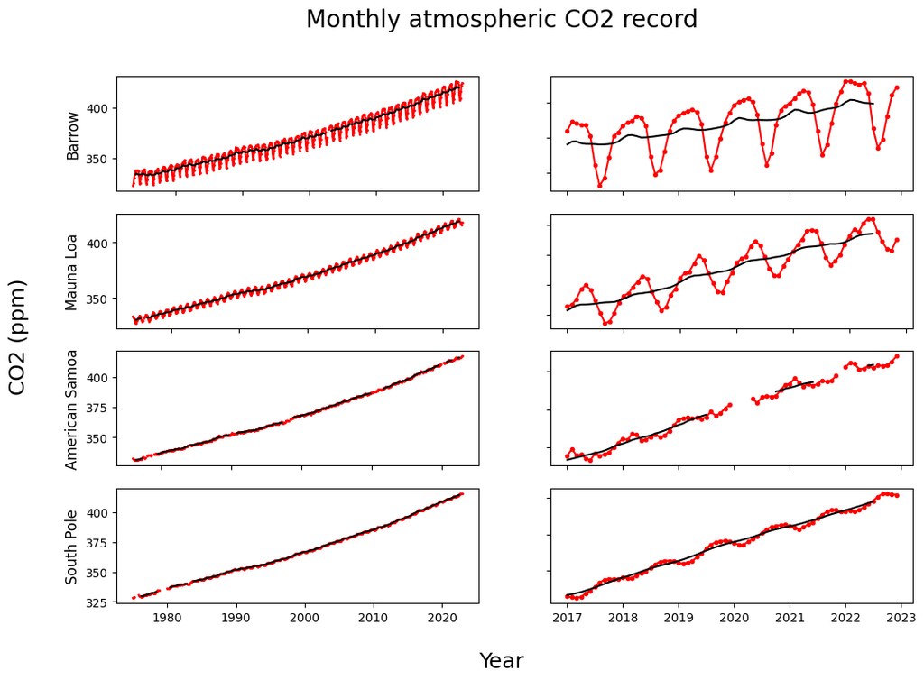

```python
fig, axs = plt.subplots(4, 2, figsize=(12, 8))
axes = [[0, 0], [0, 1], [1, 0], [1, 1], [2, 0], [2, 1], [3, 0], [3, 1]]
fig.suptitle("Monthly atmospheric CO2 record", fontsize=20)

cpt = 0
for obs_name in observatories:
    # Importing the data
    filename = f"co2_{obs_name}_surface-insitu_1_ccgg_MonthlyData.txt"
    df_noaa = read_noaa_data(filename)
    df_noaa = add_rollmean(df_noaa)

    # First plot, since the beginning
    i = axes[cpt][0]
    j = axes[cpt][1]
    axs[i, j].plot(df_noaa["time_decimal"], df_noaa["value"], '-o',
                   color="red", markersize=1)
    axs[i, j].plot(df_noaa["time_decimal"], df_noaa["rolling_mean"],
                   color="black")
    # Plot legends
    axs[i, j].set(ylabel=observatories[obs_name])
    axs[i, j].yaxis.get_label().set_fontsize(12)

    # Second plot, over the last five years
    start_year = df_noaa["year"][df_noaa.year.argmax()] - 5
    i = axes[cpt+1][0]
    j = axes[cpt+1][1]
    axs[i, j].plot(df_noaa[df_noaa["year"] >= start_year]["time_decimal"],
                   df_noaa[df_noaa["year"] >= start_year]["value"], '-o',
                   color="red", markersize=3, label="Real value")
    axs[i, j].plot(df_noaa[df_noaa["year"] >= start_year]["time_decimal"],
                   df_noaa[df_noaa["year"] >= start_year]["rolling_mean"],
                   color="black")

    cpt += 2

# Hide x labels and tick labels for top plots and y ticks for right plots
for ax in axs.flat:
    ax.label_outer()

fig.supxlabel('Year', fontsize=18)
fig.supylabel('CO2 (ppm)', fontsize=18)
plt.show()
```

Each line represents an observatory, with its name written to the left. Columns show the full period of recordings on the left and the last 5 years on the right. The real value is displayed in red, whereas the rolling mean calculated earlier is shown in black.

If we zoom on the last five years for each observatory, we can see why the rolling average was necessary.

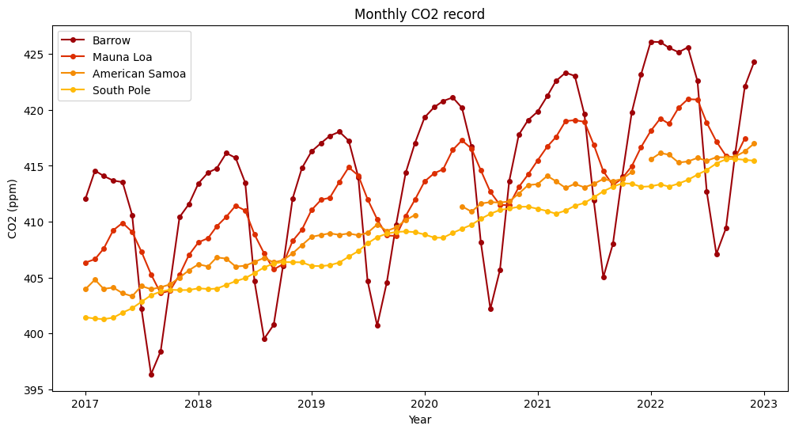

```python
colors = ["#9d0208", "#dc2f02", "#f48c06", "#ffba08"]
cpt = 0
plt.figure(figsize=(12, 6))
for obs_name in observatories:
    filename = f"co2_{obs_name}_surface-insitu_1_ccgg_MonthlyData.txt"
    df_noaa = read_noaa_data(filename)
    df_noaa = add_rollmean(df_noaa)
    start_year = df_noaa["year"][df_noaa.year.argmax()] - 5

    plt.plot(df_noaa[df_noaa["year"] >= start_year]["time_decimal"],
             df_noaa[df_noaa["year"] >= start_year]["value"], '-o',
             markersize=4, color=colors[cpt], label=observatories[obs_name])

    plt.legend(loc="upper left")
    cpt += 1
plt.xlabel("Year")
plt.ylabel("CO2 (ppm)")
plt.title("Monthly CO2 record")
plt.show()
```

If we focus on the raw value, they are all very different depending on the observatory. However if we focus on the averaged value, we can assume they all increase in the same way. To make sure of this, we will calculate the slope of a linear least-squares regression fitted to each observatory, and compare the values obtained. From the multiple models, we can extrapolate the data to predict CO2 records up until 2050.

```python
predictions = pd.DataFrame(list(range(2023, 2051)))
```

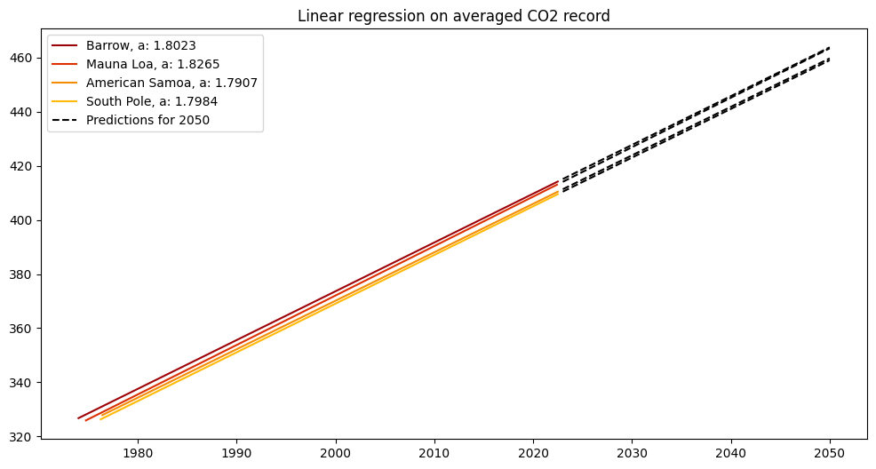

```python
cpt = 0
plt.figure(figsize=(12, 6))
for obs_name in observatories:
    filename = f"co2_{obs_name}_surface-insitu_1_ccgg_MonthlyData.txt"
    df_noaa = read_noaa_data(filename)
    df_noaa = add_rollmean(df_noaa)
    df_noaa = df_noaa.dropna()
    res = stats.linregress(df_noaa["time_decimal"], df_noaa["rolling_mean"])
    plt.plot(df_noaa["time_decimal"],
             res.intercept + res.slope*df_noaa["time_decimal"],
             color=colors[cpt], label=(f"{observatories[obs_name]}, "
             f"a: {res.slope:.4f}"))
    plt.plot(predictions, res.intercept + res.slope*predictions,
             color="black", linestyle='--')
    cpt += 1
pred_leg = plt.plot([], [], label="Predictions for 2050", color="black",
                    linestyle='--')
plt.legend(loc="upper left")
plt.title("Linear regression on averaged CO2 record")
plt.show()
```

We can conclude that although the CO2 recorded seems vastly different depending on the observatory, it rises in the same way no matter where it's measured. However it may be possible that a linear least-squares regression isn't the best fit for our values. We will therefore try an exponential regression. We followed the following [tutorial](https://www.statology.org/exponential-regression-python/).

```python
def exp_model(x, a, b):
    """Calculate an exponential regression.

    Parameters
    ----------
    x : float
        The predictor variable.
    a, b : float
        The regression coefficients that describe the relationship
        between x and y.
    Returns
    -------
    float :
        The response variable.
    """
    y = np.exp(a) * (np.exp(b) ** x)
    return y
```

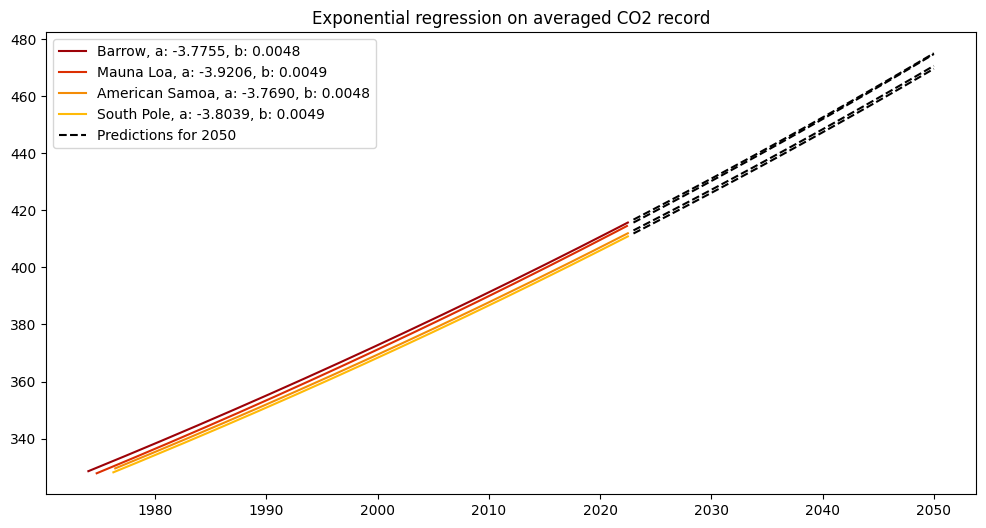

```python
cpt = 0
plt.figure(figsize=(12, 6))
for obs_name in observatories:
    filename = f"co2_{obs_name}_surface-insitu_1_ccgg_MonthlyData.txt"
    df_noaa = read_noaa_data(filename)
    df_noaa = add_rollmean(df_noaa)
    df_noaa = df_noaa.dropna()
    fit = np.polyfit(df_noaa["time_decimal"],
                     np.log(df_noaa["rolling_mean"]), 1)
    plt.plot(df_noaa["time_decimal"], exp_model(df_noaa["time_decimal"],
             fit[1], fit[0]), color=colors[cpt],
             label=(f"{observatories[obs_name]}, "
             f"a: {fit[1]:.4f}, b: {fit[0]:.4f}"))
    plt.plot(predictions, exp_model(predictions, fit[1], fit[0]),
             color="black", linestyle='--')
    cpt += 1
pred_leg = plt.plot([], [], label="Predictions for 2050", color="black",
                    linestyle='--')
plt.legend(loc="upper left")
plt.title("Exponential regression on averaged CO2 record")
plt.show()
```

If CO2 records fit an exponential regression rather than a linear regression, atmospheric CO2 will increase quicker. For instance, we barely exceed 460ppm by 2050 using a linear regression, but we almost reach 480ppm using an exponential one.

#### Paleoclimatology

##### From the year 1000 to 2004

The dataset is also stored in a text format, but uses tabulations as the separator and contains 23 columns for 1005 lines. It contains the year of recording, from 1000 to 2004, and three mains values : the record at Law Dome (LD), the record at Dronning Maud Land (DML) and the average record over thoses two sites. Each of theses values is smoothed with splines ranging from 50 to 200 years with a 25 year step.

```python
filename = "smoothedco2.txt"
if not Path(filename).is_file():
    urlretrieve(
        ("https://www.ncei.noaa.gov/pub/data/paleo/contributions_by_author/"
         "frank2010/smoothedco2.txt"),
        filename,
    )

df_indus = pd.read_csv(filename, sep='\t', header=0)
df_indus.head()
```

|  | Year | ALL_50_full | LD_050 | DML_050 | ALL_050 | LD_075 | DML_075 | ALL_075 | LD_100 | DML_100 | ... | ALL_125 | LD_150 | DML_150 | ALL_150 | LD_175 | DML_175 | ALL_175 | LD_200 | DML_200 | ALL_200 |
| --- | --- | --- | --- | --- | --- | --- | --- | --- | --- | --- | --- | --- | --- | --- | --- | --- | --- | --- | --- | --- | --- |
| 0 | 1000 | 278.66 | NaN | NaN | NaN | NaN | NaN | NaN | NaN | NaN | ... | NaN | NaN | NaN | NaN | NaN | NaN | NaN | NaN | NaN | NaN |
| 1 | 1001 | 278.68 | NaN | NaN | NaN | NaN | NaN | NaN | NaN | NaN | ... | NaN | NaN | NaN | NaN | NaN | NaN | NaN | NaN | NaN | NaN |
| 2 | 1002 | 278.69 | NaN | NaN | NaN | NaN | NaN | NaN | NaN | NaN | ... | NaN | NaN | NaN | NaN | NaN | NaN | NaN | NaN | NaN | NaN |
| 3 | 1003 | 278.71 | NaN | NaN | NaN | NaN | NaN | NaN | NaN | NaN | ... | NaN | NaN | NaN | NaN | NaN | NaN | NaN | NaN | NaN | NaN |
| 4 | 1004 | 278.72 | NaN | NaN | NaN | NaN | NaN | NaN | NaN | NaN | ... | NaN | NaN | NaN | NaN | NaN | NaN | NaN | NaN | NaN | NaN |

5 rows × 23 columns

Just by looking at the data, we can see there is a lot of missing values.

```python
df_indus.isna().sum()
```

```
Year             0
ALL_50_full      0
LD_050         254
DML_050        254
ALL_050        254
LD_075         254
DML_075        254
ALL_075        254
LD_100         254
DML_100        254
ALL_100        254
LD_125         254
DML_125        254
ALL_125        254
LD_150         254
DML_150        254
ALL_150        254
LD_175         254
DML_175        254
ALL_175        254
LD_200         254
DML_200        254
ALL_200        254
dtype: int64
```

'*ALL_50_full*' has the least amount of missing data. Therefore, we will only take into account, the years and the value for both sites with a 50 year splines.

```python
df_indus = df_indus[["Year", "ALL_50_full"]]
df_indus.describe()
```

|  | Year | ALL_50_full |
| --- | --- | --- |
| count | 1005.000000 | 1005.000000 |
| mean | 1502.000000 | 284.887801 |
| std | 290.262812 | 14.310892 |
| min | 1000.000000 | 276.450000 |
| 25% | 1251.000000 | 279.600000 |
| 50% | 1502.000000 | 280.980000 |
| 75% | 1753.000000 | 282.100000 |
| max | 2004.000000 | 372.930000 |

```python
df_mlo["value"] = df_mlo["value"].replace(-999.99, None)
df_mlo = add_rollmean(df_mlo)
df_mlo = df_mlo[["year", "rolling_mean"]]
df_mlo = df_mlo.groupby(["year"])[["rolling_mean"]].mean()
df_mlo = df_mlo.rename_axis("year").reset_index()
df_mlo = df_mlo.rename(columns={"year": "Year", "rolling_mean": "ALL_50_full"})
df_mlo.head()
```

|  | Year | ALL_50_full |
| --- | --- | --- |
| 0 | 1973 | NaN |
| 1 | 1974 | 330.246970 |
| 2 | 1975 | 331.001364 |
| 3 | 1976 | 332.148831 |
| 4 | 1977 | 333.823409 |

We want to keep ice cores values from 1000 to 1974 and get Mauna Loa values from 1974 to now.

```python
df_indus_new = pd.concat([df_indus[df_indus["Year"] < 1974],
                          df_mlo[df_mlo["Year"] > 1973]],
                         axis=0)
df_indus_new.tail()
```

|  | Year | ALL_50_full |
| --- | --- | --- |
| 45 | 2018 | 408.782197 |
| 46 | 2019 | 411.648636 |
| 47 | 2020 | 414.177424 |
| 48 | 2021 | 416.408636 |
| 49 | 2022 | 418.103485 |

We can now see atmospheric CO2 records from 1000 to now. This way, we can also focus on atmospheric CO2 records after the pre-industrial era, around 1750.

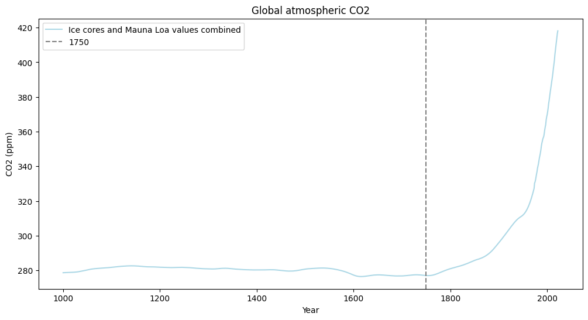

```python
plt.figure(figsize=(12, 6))
plt.plot(df_indus_new["Year"],
         df_indus_new["ALL_50_full"],
         color="lightblue", label="Ice cores and Mauna Loa values combined")
plt.axvline(x=1750, linestyle='--', color="grey", label="1750")

plt.title("Global atmospheric CO2")
plt.xlabel("Year")
plt.ylabel("CO2 (ppm)")
plt.legend(loc="upper left")
plt.show()
```

We can clearly see how before 1750, atmospheric CO2 was oscillating around 280 ppm. After 1750, it skyrockets up to 418 ppm in 2022.

##### 800,000 years before present

The dataset is once again stored in a text format, also uses tabulations as the separator and contains 2 columns for 1096 lines. It contains the year before present, meaning [before 1950](https://www.artobatours.com/articles/archaeology/bp-bc-bce-ad-ce-cal-mean/), and the CO2 records. This means that for instance, the first year being 137 BP is actually the year 1813. This has to changed in order for the plot to be displayed correctly.

```python
filename = "edc3-composite-co2-2008-noaa.txt"
if not Path(filename).is_file():
    urlretrieve(
        ("https://www.ncei.noaa.gov/pub/data/paleo/icecore/antarctica/"
         "epica_domec/edc3-composite-co2-2008-noaa.txt"),
        filename,
    )

df_icecore = pd.read_csv(filename, comment='#', sep='\t', header=0)
df_icecore.head()
```

|  | gas_ageBP | CO2 |
| --- | --- | --- |
| 0 | 137 | 280.4 |
| 1 | 268 | 274.9 |
| 2 | 279 | 277.9 |
| 3 | 395 | 279.1 |
| 4 | 404 | 281.9 |

```python
df_icecore.describe()
```

|  | gas_ageBP | CO2 |
| --- | --- | --- |
| count | 1096.000000 | 1096.000000 |
| mean | 390905.979015 | 230.835675 |
| std | 262092.947239 | 27.573616 |
| min | 137.000000 | 171.600000 |
| 25% | 137133.500000 | 207.500000 |
| 50% | 423206.500000 | 231.450000 |
| 75% | 627408.000000 | 251.525000 |
| max | 798512.000000 | 298.600000 |

```python
df_icecore["gas_ageBP"] = 1950 - df_icecore["gas_ageBP"]
df_icecore.head()
```

|  | gas_ageBP | CO2 |
| --- | --- | --- |
| 0 | 1813 | 280.4 |
| 1 | 1682 | 274.9 |
| 2 | 1671 | 277.9 |
| 3 | 1555 | 279.1 |
| 4 | 1546 | 281.9 |

This time we want to visualize our data based on its origins, wether it's from ice cores, industria ice cores or observatories like Mauna Loa's. We can use previous dataframes.

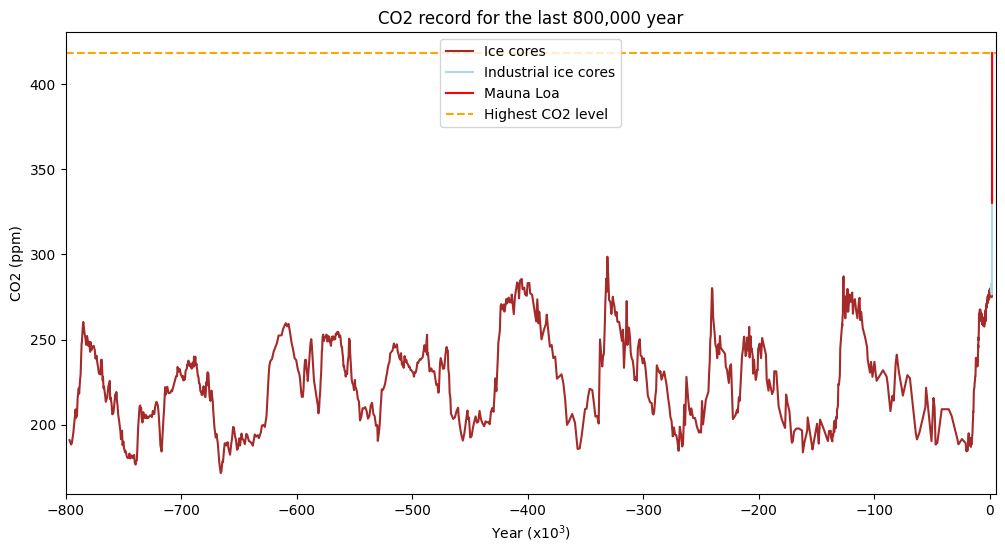

```python
plt.figure(figsize=(12, 6))
plt.plot(df_icecore["gas_ageBP"] / 1000,
         df_icecore["CO2"],
         color="brown", label="Ice cores")

plt.plot(df_indus["Year"]/1000,
         df_indus["ALL_50_full"],
         color="lightblue", label="Industrial ice cores")

plt.plot(df_mlo["Year"]/1000,
         df_mlo["ALL_50_full"],
         color="red", label="Mauna Loa")

plt.xlim([-800, 5])
plt.title("CO2 record for the last 800,000 year")
plt.xlabel("Year (x$10^3$)")
plt.ylabel("CO2 (ppm)")
max_year = df_indus_new["Year"].max()
max_value = df_indus_new[df_indus_new["Year"] == max_year]["ALL_50_full"]
plt.axhline(float(max_value), linestyle='--', color="orange",
            label="Highest CO2 level")
plt.legend(loc='upper center')
plt.show()
```

Zooming on CO2 records after 1750, we can see how the highest historical CO2 record was surpassed soon after 1900. After 1950, it rose even moreso than before, and keeps on rising.

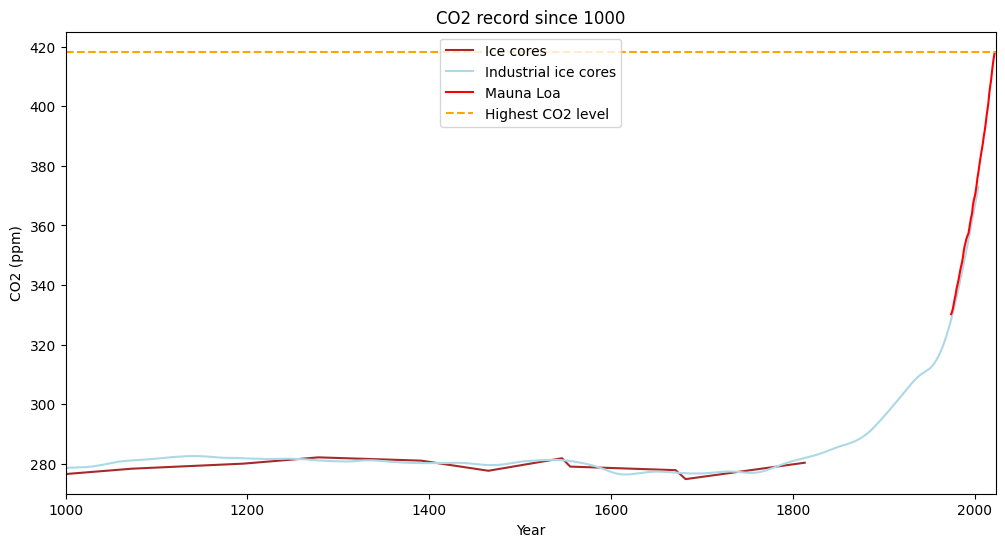

```python
plt.figure(figsize=(12, 6))
plt.plot(df_icecore["gas_ageBP"],
         df_icecore["CO2"],
         color="brown", label="Ice cores")

plt.plot(df_indus["Year"],
         df_indus["ALL_50_full"],
         color="lightblue", label="Industrial ice cores")

plt.plot(df_mlo["Year"],
         df_mlo["ALL_50_full"],
         color="red", label="Mauna Loa")

start = 1000
plt.xlim([start, 2023])
plt.ylim([270, 425])
plt.title(f"CO2 record since {start}")
plt.xlabel("Year")
plt.ylabel("CO2 (ppm)")
plt.axhline(float(max_value), linestyle='--', color="orange",
            label="Highest CO2 level")
plt.legend(loc='upper center')
plt.show()
```

Even though CO2 records from ice cores are only estimated and come from different locations, they seem to follow real measured values from Mauna Loa.

## Temperature anomalies

The evolution of the world's climate is not measured and rendered using actual temperature values, but rather temperature [*anomalies*](https://www.carbonbrief.org/explainer-how-do-scientists-measure-global-temperature/). Scientists combine measurements from the air above land and the ocean surface, and this measure is compared daily to what is 'normal' for that location and time, typically the long-term average over a 30-year period. These anomalies are the temperature differences observed.

To take account of the diversity of the world's regions, temperatures are measured on a special global grid where each box is usually 5° by 5°. Global yearly temperature anomalies are an average of each annual grid value.

### Data source

Scientists use four major datasets to study global temperature:

- [GISTEMP](https://data.giss.nasa.gov/gistemp/), by the NASA Goddard Institute for Space Sciences ([GISS](https://www.giss.nasa.gov/))
- [HadCRUT5](https://www.metoffice.gov.uk/hadobs/hadcrut5/), by the UK [Met Office Hadley Centre](https://www.metoffice.gov.uk/weather/climate/met-office-hadley-centre/index) and the [University of East Anglia’s Climatic Research Unit](https://www.uea.ac.uk/groups-and-centres/climatic-research-unit)
- [NOAAGlobalTemp](https://www.ncei.noaa.gov/products/land-based-station/noaa-global-temp) (formely know as MLOST), by the National Oceanic and Atmospheric Administration ([NOAA](https://www.noaa.gov/))
- [JMA](https://ds.data.jma.go.jp/tcc/tcc/products/gwp/temp/explanation.html), by the Japan Meteorological Agency

#### GISTEMP

The GISS Surface Temperature Analysis (GISTEMP) is an estimate of global surface temperature change. Measures date back to 1880 up until now, and temperature anomalies are deviations from the corresponding 1951-1980 means. Data combines land-surface air and sea-surface water temperature anomalies using files from [NOAA GHCN v4](https://www.ncei.noaa.gov/products/land-based-station/global-historical-climatology-network-daily) (meteorological stations) and [ERSST v5](https://www.ncei.noaa.gov/products/extended-reconstructed-sst) (ocean areas).

Data are plain-text files in tabular format of temperature anomalies (*txt* or *csv*). Users interested in the entire gridded surface air temperature anomaly data may download netCDF files containing selected series on a regular 2°×2° grid or the basic SBBX binary files.

#### HadCRUT5

HadCRUT5 is a gridded dataset of global historical surface temperature anomalies relative to a 1961-1990 reference period. Data are available for each month from January 1850 onwards, on a 5 degree grid and as global and regional average time series. The gridded data are a blend of the [CRUTEM5](https://www.metoffice.gov.uk/hadobs/crutem5/) land-surface air temperature dataset and the [HadSST4](https://www.metoffice.gov.uk/hadobs/hadsst4/) sea-surface temperature (SST) dataset.

Time series data are provided in CSV and NetCDF formats.

#### NOAAGlobalTemp

The NOAA Merged Land Ocean Global Surface Temperature Analysis (NOAAGlobalTemp) combines long-term sea surface (water) temperature (SST) and land surface (air) temperature datasets to create a complete, accurate depiction of global temperature trends. The dataset is used to support climate monitoring activities such as the Monthly Global Climate Assessment, and also provides input data for a number of climate models.

Data is available as a series of temperature anomalies relative to a 1971–2000 monthly climatology. Monthly and annual land–ocean temperature time series as well as land-only and ocean-only time series are available from 1850 to present for several zonal bands.

Global Gridded 5° Monthly data are available in netCDF format.

#### JMA

JMA estimates global temperature anomalies using data combined not only over land but also over ocean areas in each 5° x 5° grid box worldwide. Temperature anomalies are measured from the 1991-2020 baseline since 1891.

Data are stored in ASCII.

#### Temperature estimates before real measurements, paleoclimatology

Past temperatures are [measured](https://www.theguardian.com/environment/2012/mar/07/past-climate-temperature-proxies) using natural archives such as ice, rocks and fossils. However, temperature is not measured directly, but is instead inferred from special chemical properties, like the isotopic composition of the water molecules released by melting the [ice cores](https://www.scientificamerican.com/article/how-are-past-temperatures/).

We will be using the data computed by [Osman et al.](https://www-nature-com.ezproxy.u-paris.fr/articles/s41586-020-2617-x#Sec7), in 2021.

### Unit of measurement

Daily anomalies are averaged together over a whole month. These are, in turn, used to work out temperature anomalies from season-to-season and year-to-year. A 'positive' anomaly means the temperature is warmer than the long-term average, whereas a 'negative' anomaly means it’s cooler. All anomalies are measured using degree Celsius (°C).

### Data analysis

```python
import matplotlib.pyplot as plt
import pandas as pd
from pathlib import Path
from urllib.request import urlretrieve
import urllib.parse
from matplotlib.colors import LinearSegmentedColormap
import numpy as np
import gzip
import xarray as xr
import openpyxl
```

#### GISTEMP (1880-2022)

```python
filename = "ZonAnn.Ts+dSST.csv"
if not Path(filename).is_file():
    urlretrieve(
        "https://data.giss.nasa.gov/gistemp/tabledata_v4/ZonAnn.Ts+dSST.csv",
        filename,
    )

df_gistemp = pd.read_csv(filename, sep=',', header=0)
df_gistemp.head()
```

|  | Year | Glob | NHem | SHem | 24N-90N | 24S-24N | 90S-24S | 64N-90N | 44N-64N | 24N-44N | EQU-24N | 24S-EQU | 44S-24S | 64S-44S | 90S-64S |
| --- | --- | --- | --- | --- | --- | --- | --- | --- | --- | --- | --- | --- | --- | --- | --- |
| 0 | 1880 | -0.17 | -0.29 | -0.05 | -0.38 | -0.13 | -0.02 | -0.81 | -0.50 | -0.28 | -0.14 | -0.11 | -0.05 | 0.05 | 0.67 |
| 1 | 1881 | -0.09 | -0.18 | -0.01 | -0.36 | 0.11 | -0.08 | -0.93 | -0.49 | -0.20 | 0.11 | 0.10 | -0.06 | -0.07 | 0.60 |
| 2 | 1882 | -0.11 | -0.21 | -0.02 | -0.32 | -0.04 | 0.01 | -1.42 | -0.30 | -0.15 | -0.03 | -0.05 | 0.00 | 0.04 | 0.63 |
| 3 | 1883 | -0.18 | -0.29 | -0.07 | -0.36 | -0.16 | -0.02 | -0.19 | -0.58 | -0.28 | -0.17 | -0.16 | -0.05 | 0.07 | 0.50 |
| 4 | 1884 | -0.29 | -0.43 | -0.15 | -0.62 | -0.14 | -0.14 | -1.31 | -0.66 | -0.48 | -0.12 | -0.17 | -0.20 | -0.02 | 0.65 |

```python
df_gistemp.shape
```

```
(143, 15)
```

```python
df_gistemp.describe()
```

|  | Year | Glob | NHem | SHem | 24N-90N | 24S-24N | 90S-24S | 64N-90N | 44N-64N | 24N-44N | EQU-24N | 24S-EQU | 44S-24S | 64S-44S | 90S-64S |
| --- | --- | --- | --- | --- | --- | --- | --- | --- | --- | --- | --- | --- | --- | --- | --- |
| count | 143.00000 | 143.000000 | 143.000000 | 143.000000 | 143.00000 | 143.000000 | 143.000000 | 143.000000 | 143.000000 | 143.000000 | 143.000000 | 143.000000 | 143.00000 | 143.000000 | 143.000000 |
| mean | 1951.00000 | 0.059790 | 0.090000 | 0.030909 | 0.11049 | 0.069930 | -0.003566 | 0.255944 | 0.131469 | 0.038811 | 0.062448 | 0.077483 | 0.04000 | -0.056853 | -0.077902 |
| std | 41.42463 | 0.367081 | 0.441859 | 0.312026 | 0.53471 | 0.341815 | 0.310836 | 0.997985 | 0.589028 | 0.417669 | 0.343065 | 0.347509 | 0.33019 | 0.274540 | 0.761667 |
| min | 1880.00000 | -0.480000 | -0.560000 | -0.480000 | -0.67000 | -0.620000 | -0.480000 | -1.770000 | -0.790000 | -0.620000 | -0.660000 | -0.580000 | -0.44000 | -0.550000 | -2.600000 |
| 25% | 1915.50000 | -0.200000 | -0.210000 | -0.215000 | -0.29500 | -0.190000 | -0.240000 | -0.365000 | -0.305000 | -0.240000 | -0.200000 | -0.170000 | -0.22000 | -0.260000 | -0.530000 |
| 50% | 1951.00000 | -0.060000 | 0.000000 | -0.060000 | 0.02000 | 0.000000 | -0.080000 | 0.090000 | -0.020000 | -0.070000 | 0.010000 | 0.000000 | -0.06000 | -0.080000 | 0.040000 |
| 75% | 1986.50000 | 0.265000 | 0.250000 | 0.270000 | 0.36000 | 0.295000 | 0.255000 | 0.760000 | 0.415000 | 0.150000 | 0.280000 | 0.305000 | 0.28500 | 0.190000 | 0.445000 |
| max | 2022.00000 | 1.010000 | 1.350000 | 0.740000 | 1.67000 | 1.000000 | 0.700000 | 3.240000 | 1.820000 | 1.270000 | 0.970000 | 1.060000 | 0.80000 | 0.440000 | 1.350000 |

```python
def showyourstripes(ax, anomaly, year, start_average, end_average, title=True):
    """Display temperature anomalies as stripes.

    Parameters
    ----------
    ax : matplotlib.axes._axes.Axes
        The axes on which to plot the stripes.
    anomaly : vector
        Temperature anomalies.
    year : vector
        Years of measures.
    start_average : int
        Beginning year of the reference period.
    end_average : int
        Last year of the reference period.
    """
    # Creating the gradient
    cmap = LinearSegmentedColormap.from_list('custom_colormap',
                                             ['#08306B', '#4292C6',
                                              '#C6DBEF', 'white',
                                              '#FB6A4A', '#EF3B2C',
                                              '#67000D'], N=len(anomaly))
    normalized = ((np.array(anomaly) - min(anomaly)) /
                  (max(anomaly) - min(anomaly)))
    colors = cmap(normalized)

    # Stripes plot
    ax.bar(year, [1] * len(year), color=colors, width=1)

    # Legends
    ax.set_facecolor('black')
    ax.set_xlim([min(year), max(year)])
    ax.set_ylim([0, 1])
    ax.yaxis.set_visible(False)
    if (title):
        ax.set_title("Relative to average of "
                     f"{start_average}-{end_average} (°C)", fontsize=10)
        ax.set_title(f"Global temperature change ({min(year)}-{max(year)})")
```

```python
def showyourbars(ax, anomaly, year, start_average, end_average, title=True):
    """Display temperature anomalies as bars.

    Parameters
    ----------
    ax : matplotlib.axes._axes.Axes
        The axes on which to plot the bars.
    anomaly : vector
        Temperature anomalies.
    year : vector
        Years of measures.
    start_average : int
        Beginning year of the reference period.
    end_average : int
        Last year of the reference period.
    """
    # Creating the gradient
    cmap = LinearSegmentedColormap.from_list('custom_colormap',
                                             ['#08306B', '#4292C6',
                                              '#C6DBEF', 'white',
                                              '#FB6A4A', '#EF3B2C',
                                              '#67000D'], N=len(anomaly))
    normalized = ((np.array(anomaly) - min(anomaly)) /
                  (max(anomaly) - min(anomaly)))
    colors = cmap(normalized)

    # Bar plot
    ax.bar(year, anomaly, color=colors, width=1)

    # Legends
    ax.set_facecolor('black')
    ax.set_xlim([min(year), max(year)])
    ax.set_ylim([min(anomaly), max(anomaly)])
    if (title):
        ax.set_title("Relative to average of "
                     f"{start_average}-{end_average} (°C)", fontsize=10)
        ax.set_title(f"Global temperature change ({min(year)}-{max(year)})")
```

```python
def showtempanalysis(name, anomaly, year, start_average, end_average):
    """Display temperature anomalies analysis.

    Shows both bars and stripes for the data.

    Parameters
    ----------
    name : string
        Name of the measurement technique.
    anomaly : vector
        Temperature anomalies.
    year : vector
        Years of measures.
    start_average : int
        Beginning year of the reference period.
    end_average : int
        Last year of the reference period.
    """
    fig, ax = plt.subplots(1, 2, figsize=(16, 6))
    showyourbars(ax[0], anomaly, year, start_average, end_average, title=False)
    showyourstripes(ax[1], anomaly, year,
                    start_average, end_average, title=False)
    fig.suptitle(f"{name} - Global temperature change "
                 f"({min(year)}-{max(year)})\nRelative to average of "
                 f"{start_average}-{end_average} (°C)", fontsize=15)
    plt.show()
```

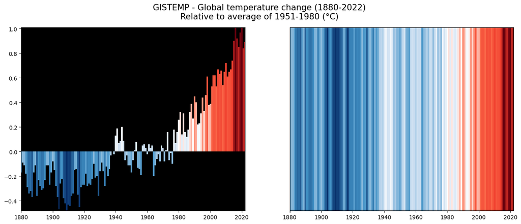

```python
start_average = 1951
end_average = 1980
showtempanalysis("GISTEMP", df_gistemp["Glob"],
                 df_gistemp["Year"], start_average, end_average)
```

Before the baseline, we can see how temperatures were colder and became warmer with time. At most, recent temperatures are more than a degree C° warmer.

#### HadCRUT5 (1850-2023)

Time series data are provided in CSV (comma-separated values). This specific dataset contains 4 columns and 174 lines, corresponding to the years between 1850 and 2023. Here we want to focus on the two first columns : the year and the global temperature anomaly observed. Temperature anomalies are computed as the difference between the means of regional time series computed for each of the 200 ensemble member realisations and the baseline of 1961-1990.

```python
filename = "HadCRUT.5.0.1.0.analysis.summary_series.global.annual.csv"
if not Path(filename).is_file():
    urlretrieve(
        ("https://www.metoffice.gov.uk/hadobs/hadcrut5/data/"
         "HadCRUT.5.0.2.0/analysis/diagnostics/"
         "HadCRUT.5.0.2.0.analysis.summary_series.global.annual.csv"),
        filename,
    )

df_crut5 = pd.read_csv(filename, sep=',', header=0)
df_crut5.head()
```

|  | Time | Anomaly (deg C) | Lower confidence limit (2.5%) | Upper confidence limit (97.5%) |
| --- | --- | --- | --- | --- |
| 0 | 1850 | -0.417711 | -0.589256 | -0.246166 |
| 1 | 1851 | -0.233350 | -0.411868 | -0.054832 |
| 2 | 1852 | -0.229399 | -0.409382 | -0.049416 |
| 3 | 1853 | -0.270354 | -0.430009 | -0.110700 |
| 4 | 1854 | -0.291521 | -0.432712 | -0.150330 |

```python
df_crut5.describe()
```

|  | Time | Anomaly (deg C) | Lower confidence limit (2.5%) | Upper confidence limit (97.5%) |
| --- | --- | --- | --- | --- |
| count | 174.000000 | 174.000000 | 174.000000 | 174.000000 |
| mean | 1936.500000 | -0.072390 | -0.168021 | 0.023241 |
| std | 50.373604 | 0.378517 | 0.415464 | 0.345198 |
| min | 1850.000000 | -0.597511 | -0.724956 | -0.470066 |
| 25% | 1893.250000 | -0.341295 | -0.483914 | -0.209894 |
| 50% | 1936.500000 | -0.175571 | -0.261326 | -0.075096 |
| 75% | 1979.750000 | 0.087551 | 0.015117 | 0.196974 |
| max | 2023.000000 | 1.060965 | 1.003149 | 1.118780 |

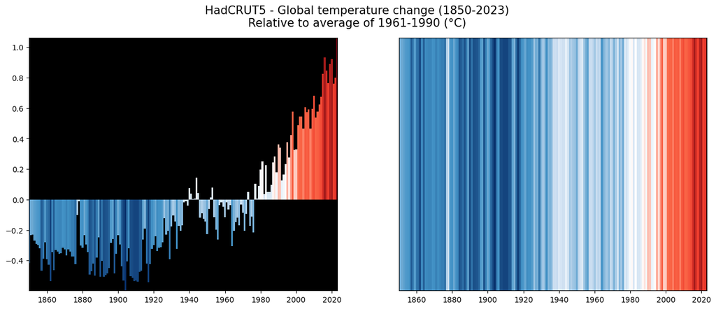

```python
start_average = 1961
end_average = 1990
showtempanalysis("HadCRUT5", df_crut5["Anomaly (deg C)"],
                 df_crut5["Time"], start_average, end_average)
```

We can observe the same results as with GISTEMP : temperatures are increasing with time.

#### NOAAGlobalTemp (1850-2023)

Global Gridded 5° Monthly temperature anomalies are available in netCDF format, which is a [file format](https://pro.arcgis.com/en/pro-app/latest/help/data/multidimensional/what-is-netcdf-data.htm) for storing multidimensional scientific data, using 1971-2000 as the baseline. Here, we only want data displayed through time. We can therefore convert the data into a dataframe.

```python
filename = "NOAAGlobalTemp_v5.1.0_gridded_s185001_e202310_c20231108T150201.nc"
if not Path(filename).is_file():
    urlretrieve(
        ("https://www.ncei.noaa.gov/data/noaa-global-surface-"
         "temperature/v5.1/access/gridded/NOAAGlobalTemp_v5.1.0_"
         "gridded_s185001_e202310_c20231108T150201.nc"),
        filename,
    )
```

```python
df_noaa = xr.open_dataset(filename)
df_noaa = df_noaa.to_dataframe()
df_noaa = df_noaa.reset_index()
df_noaa.tail()
```

|  | time | lat | lon | z | anom |
| --- | --- | --- | --- | --- | --- |
| 5406907 | 2023-10-01 | 87.5 | 337.5 | 0.0 | 6.096656 |
| 5406908 | 2023-10-01 | 87.5 | 342.5 | 0.0 | 6.091046 |
| 5406909 | 2023-10-01 | 87.5 | 347.5 | 0.0 | 2.730000 |
| 5406910 | 2023-10-01 | 87.5 | 352.5 | 0.0 | 2.560000 |
| 5406911 | 2023-10-01 | 87.5 | 357.5 | 0.0 | 2.390000 |

```python
df_noaa.shape
```

```
(5406912, 5)
```

We obtain a dataframe containing 5406912 rows. This corresponds to each value observed each month in the 72x36 grid, meaning each year contains 31 104 rows (except 2023 where only 10 month are recorded, meaning it groups only 25 920 lines).  
We will therefore assume that the averaged global value for each year is the average of all monthly values for each grid box.

```python
df_noaa['time'] = df_noaa['time'].astype(str)
df_noaa['year'] = df_noaa['time'].str.split('-').str[0].astype(int)
df_noaa.head()
```

|  | time | lat | lon | z | anom | year |
| --- | --- | --- | --- | --- | --- | --- |
| 0 | 1850-01-01 | -87.5 | 2.5 | 0.0 | -0.179675 | 1850 |
| 1 | 1850-01-01 | -87.5 | 7.5 | 0.0 | -0.179675 | 1850 |
| 2 | 1850-01-01 | -87.5 | 12.5 | 0.0 | -0.179675 | 1850 |
| 3 | 1850-01-01 | -87.5 | 17.5 | 0.0 | -0.179675 | 1850 |
| 4 | 1850-01-01 | -87.5 | 22.5 | 0.0 | -0.179675 | 1850 |

```python
noaa_mean = df_noaa.groupby('year')["anom"].mean()
noaa_mean = noaa_mean.tolist()

noaa_year = set(df_noaa["year"].astype(int))
noaa_year = list(noaa_year)
noaa_year.sort()

df_noaa = pd.DataFrame({'Year': noaa_year, 'Value': noaa_mean})
df_noaa.describe()
```

|  | Year | Value |
| --- | --- | --- |
| count | 174.000000 | 174.000000 |
| mean | 1936.500000 | -0.229794 |
| std | 50.373604 | 0.380327 |
| min | 1850.000000 | -0.695069 |
| 25% | 1893.250000 | -0.492750 |
| 50% | 1936.500000 | -0.362359 |
| 75% | 1979.750000 | -0.122494 |
| max | 2023.000000 | 0.936130 |

```python
df_noaa.head()
```

|  | Year | Value |
| --- | --- | --- |
| 0 | 1850 | -0.464625 |
| 1 | 1851 | -0.366157 |
| 2 | 1852 | -0.393759 |
| 3 | 1853 | -0.399670 |
| 4 | 1854 | -0.380015 |

Now that we've computed the global average yearly anomalies, we can visualize them.

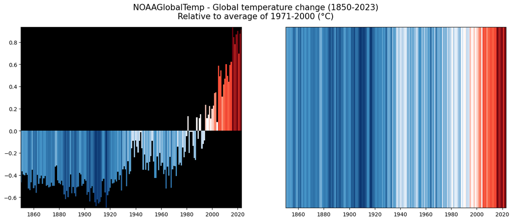

```python
start_average = 1971
end_average = 2000
showtempanalysis("NOAAGlobalTemp", df_noaa["Value"],
                 df_noaa["Year"], start_average, end_average)
```

Likewise, temperature are still increasing every year.

#### JMA (1891-2022)

Annual anomalies of the JMA's Global Surface Temperature are an average of monthly values, by the same 5° x 5° grid boxes as usual, compared to the 1991-2020 baseline. The complete annual dataset contains 36x72 values, corresponding to each grid boxes, by year. This means that the file contains 4752 rows, 36 for each year between 1891 and 2022, and 72 columns.  
We will therefore assume that the averaged global value for each year is the average of the 36x72 values.

```python
filename = "gst_ann_1891_last.gz"
if not Path(filename).is_file():
    urlretrieve(
        ("https://ds.data.jma.go.jp/tcc/tcc/products/gwp/temp/map/grid/"
         "gst_ann_1891_last.gz"),
        filename,
    )
```

```python
with gzip.open(filename) as f:
    df_jma = pd.read_csv(f, names=range(1, 73), skiprows=1,
                         delim_whitespace=True, index_col=False,
                         comment='#', na_values=-9999.00)
df_jma.head()
```

|  | 1 | 2 | 3 | 4 | 5 | 6 | 7 | 8 | 9 | 10 | ... | 63 | 64 | 65 | 66 | 67 | 68 | 69 | 70 | 71 | 72 |
| --- | --- | --- | --- | --- | --- | --- | --- | --- | --- | --- | --- | --- | --- | --- | --- | --- | --- | --- | --- | --- | --- |
| 0 | NaN | NaN | NaN | NaN | NaN | NaN | NaN | NaN | NaN | NaN | ... | NaN | NaN | NaN | NaN | NaN | NaN | NaN | NaN | NaN | NaN |
| 1 | NaN | NaN | NaN | NaN | NaN | NaN | NaN | NaN | NaN | NaN | ... | NaN | NaN | NaN | NaN | NaN | NaN | NaN | NaN | NaN | NaN |
| 2 | NaN | NaN | NaN | NaN | NaN | NaN | NaN | NaN | NaN | NaN | ... | NaN | NaN | NaN | NaN | NaN | NaN | NaN | NaN | NaN | NaN |
| 3 | NaN | NaN | NaN | NaN | NaN | NaN | -2.0 | NaN | NaN | NaN | ... | NaN | NaN | NaN | NaN | NaN | NaN | NaN | NaN | NaN | NaN |
| 4 | NaN | NaN | -0.96 | -0.72 | NaN | NaN | NaN | NaN | NaN | NaN | ... | NaN | NaN | NaN | NaN | NaN | -0.93 | -1.18 | NaN | NaN | NaN |

5 rows × 72 columns

```python
df_jma['Groupe'] = (df_jma.index // 36) + 1
jma_mean = df_jma.groupby('Groupe').mean()
jma_mean = jma_mean.mean(axis=1)
jma_mean = jma_mean.tolist()

jma_year = list(range(1891, 2023, 1))

df_jma = pd.DataFrame({'Year': jma_year, 'Value': jma_mean})
df_jma.describe()
```

|  | Year | Value |
| --- | --- | --- |
| count | 132.000000 | 132.000000 |
| mean | 1956.500000 | -0.505629 |
| std | 38.249183 | 0.353231 |
| min | 1891.000000 | -1.051868 |
| 25% | 1923.750000 | -0.735258 |
| 50% | 1956.500000 | -0.573072 |
| 75% | 1989.250000 | -0.347196 |
| max | 2022.000000 | 0.403580 |

Once all the values have been grouped together, the dataset can be analyzed.

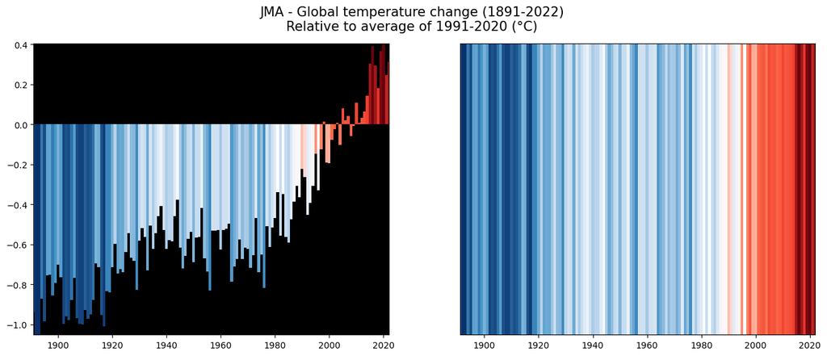

```python
start_average = 1991
end_average = 2020
showtempanalysis("JMA", df_jma["Value"],
                 df_jma["Year"], start_average, end_average)
```

The JMA uses the most recent baseline, 1991 to 2020. However, we can still see temperatures climbing with time.

#### Comparison

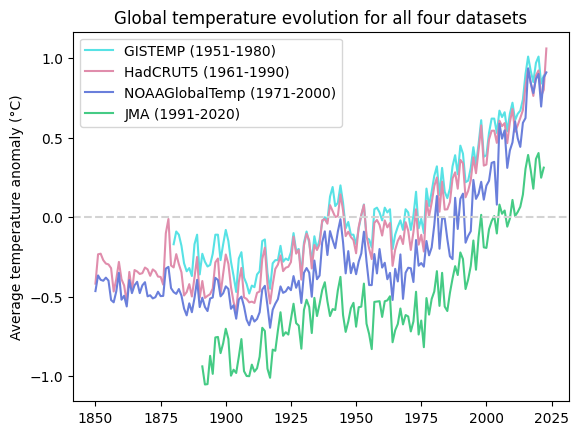

```python
# GISTEMP
plt.plot(df_gistemp["Year"], df_gistemp["Glob"], color="#57E2E5",
         label="GISTEMP (1951-1980)")
# HadCRUT5
plt.plot(df_crut5["Time"], df_crut5["Anomaly (deg C)"], color="#E08DAC",
         label="HadCRUT5 (1961-1990)")
# NOAAGlobalTemp
plt.plot(df_noaa["Year"], df_noaa["Value"], color="#6A7FDB",
         label="NOAAGlobalTemp (1971-2000)")
# JMA
plt.plot(df_jma["Year"], df_jma["Value"], color="#45CB85",
         label="JMA (1991-2020)")

# Legends
plt.axhline(0, linestyle='--', color="lightgrey")
plt.ylabel("Average temperature anomaly (°C)")
plt.title("Global temperature evolution for all four datasets")
plt.legend(loc='upper left')
plt.show()
```

Although the temperature anomalies were estimated using different reference periods, they show virtually the same trend. The main observable difference is on the y-axis, but this can be attributed to the difference in reference baselines.

#### Paleoclimatology

The data is downloadable as an excel file, which contains both the data from the study and the one from the study by [Tardif et al.](https://cp.copernicus.org/articles/15/1251/2019/) in 2019. However, reading the file as an excel returns only the data from this study, which is what we want. For every 200 years BP, we have the estimated values for each percentile.

The value is the global mean surface temperature (GMST) estimate spanning the deglacial and Holocene periods using ~80 marine and terrestrial temperature proxies ([Shakun et al.](https://www-nature-com.ezproxy.u-paris.fr/articles/nature10915) and [Marcott et al.](https://www-science-org.ezproxy.u-paris.fr/doi/10.1126/science.1228026)) compared to the preindustrial last millennium average (1000–1850 CE). To show the averaged value, we will focus on the estimated values for the 50th percentile.

Since values are estimated over 200 years, we will consider the first value of the interval as the true age. This age is BP, before present, meaning [before 1950](https://www.artobatours.com/articles/archaeology/bp-bc-bce-ad-ce-cal-mean/). Therefore, 0 BP actually means 1950. This has to be taken into account in order for the data to be displayed correctly.

```python
filename = "41586_2021_3984_MOESM3_ESM.xlsx"
if not Path(filename).is_file():
    urlretrieve(
        ("https://static-content.springer.com/esm/art%3A10.1038%2Fs41586-"
         "021-03984-4/MediaObjects/41586_2021_3984_MOESM3_ESM.xlsx"),
        filename,
    )
df_paleo = pd.read_excel(filename, usecols='A:L', skiprows=[0])
df_paleo.head()
```

|  | Age BP \ Percentile: | 5th | 10th | 20th | 30th | 40th | 50th | 60th | 70th | 80th | 90th | 95th |
| --- | --- | --- | --- | --- | --- | --- | --- | --- | --- | --- | --- | --- |
| 0 | 0-200 | -0.304488 | -0.232582 | -0.132790 | -0.052211 | 0.011223 | 0.054823 | 0.113395 | 0.180996 | 0.237780 | 0.327081 | 0.397650 |
| 1 | 200-400 | -0.380902 | -0.290630 | -0.200213 | -0.150446 | -0.091730 | -0.050907 | -0.005977 | 0.045101 | 0.106152 | 0.190043 | 0.254671 |
| 2 | 400-600 | -0.366350 | -0.301292 | -0.203558 | -0.155540 | -0.098881 | -0.049598 | -0.010046 | 0.034376 | 0.081587 | 0.151815 | 0.194402 |
| 3 | 600-800 | -0.317951 | -0.225254 | -0.151476 | -0.097087 | -0.047205 | -0.001387 | 0.035237 | 0.079651 | 0.121651 | 0.190512 | 0.230078 |
| 4 | 800-1000 | -0.219457 | -0.139026 | -0.063597 | -0.009101 | 0.043205 | 0.089685 | 0.131802 | 0.185135 | 0.237288 | 0.314351 | 0.374230 |

```python
df_paleo['Year'] = df_paleo['Age BP \\ Percentile:'].str.split('-').str[0]
df_paleo['Year'] = df_paleo['Year'].astype(int)
df_paleo["Year"] = 1950 - df_paleo["Year"]
```

```python
df_paleo.describe()
```

|  | 5th | 10th | 20th | 30th | 40th | 50th | 60th | 70th | 80th | 90th | 95th | Year |
| --- | --- | --- | --- | --- | --- | --- | --- | --- | --- | --- | --- | --- |
| count | 120.000000 | 120.000000 | 120.000000 | 120.000000 | 120.000000 | 120.000000 | 120.000000 | 120.000000 | 120.000000 | 120.000000 | 120.000000 | 120.000000 |
| mean | -3.748621 | -3.631169 | -3.486971 | -3.385943 | -3.299944 | -3.221362 | -3.143057 | -3.062159 | -2.964776 | -2.830726 | -2.721783 | -9950.000000 |
| std | 3.119485 | 3.085217 | 3.043018 | 3.011280 | 2.985682 | 2.962083 | 2.936789 | 2.913201 | 2.879823 | 2.833289 | 2.794625 | 6957.010852 |
| min | -8.188242 | -7.988345 | -7.792116 | -7.640312 | -7.489772 | -7.370059 | -7.238374 | -7.088038 | -6.945160 | -6.737929 | -6.550177 | -21850.000000 |
| 25% | -7.297588 | -7.143883 | -6.913446 | -6.771548 | -6.662531 | -6.557507 | -6.431386 | -6.308363 | -6.156885 | -5.979354 | -5.831452 | -15900.000000 |
| 50% | -3.358847 | -3.252377 | -3.118836 | -3.038502 | -2.952842 | -2.883379 | -2.809857 | -2.729753 | -2.635353 | -2.536499 | -2.450987 | -9950.000000 |
| 75% | -0.580506 | -0.501398 | -0.402421 | -0.328092 | -0.264961 | -0.214352 | -0.158217 | -0.101209 | -0.039682 | 0.037917 | 0.112262 | -4000.000000 |
| max | -0.219457 | -0.139026 | -0.063597 | -0.009101 | 0.043205 | 0.089685 | 0.131802 | 0.185135 | 0.237780 | 0.327081 | 0.397650 | 1950.000000 |

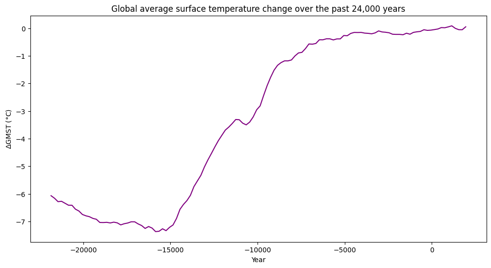

```python
plt.figure(figsize=(12, 6))
plt.plot(df_paleo["Year"], df_paleo["50th"], color="purple")
plt.title("Global average surface temperature change over the past "
          "24,000 years")
plt.xlabel("Year")
plt.ylabel("$\Delta$GMST (°C)")
plt.show()
```

Displaying all of the previous datasets next to this one has no value since the temperature anomalies are computed from the averaged value between 1000 and 1850. It would therefore show basically no variation for theses years.

### Data confirmation

True global temperature values are hard to find online, but I've managed to find [U.S. average temperatures between 1895 and 2023 for every month](https://www.ncei.noaa.gov/access/monitoring/climate-at-a-glance/national/time-series/110/tavg/1/5/1895-2023). Here we chose temperatures measured in May. Temperatures are given in Fahrenheit, with missing values being -99. We will need to take all of this into account to display the data correctly.

```python
filename = "1895-2023.csv"
if not Path(filename).is_file():
    urlretrieve(
        ("https://www.ncei.noaa.gov/access/monitoring/climate-at-a-glance/"
         "national/time-series/110/tavg/1/5/1895-2023.csv"),
        filename,
    )
```

```python
df_US = pd.read_csv(filename, sep=',', decimal=".", header=3, na_values=-99)
df_US.head()
```

|  | Date | Value |
| --- | --- | --- |
| 0 | 189505 | 59.94 |
| 1 | 189605 | 62.46 |
| 2 | 189705 | 61.18 |
| 3 | 189805 | 59.94 |
| 4 | 189905 | 59.90 |

```python
df_US['Date'] = df_US['Date'].astype(str)
df_US['Year'] = df_US['Date'].str.slice(0, 4).astype(int)
df_US.head()
```

|  | Date | Value | Year |
| --- | --- | --- | --- |
| 0 | 189505 | 59.94 | 1895 |
| 1 | 189605 | 62.46 | 1896 |
| 2 | 189705 | 61.18 | 1897 |
| 3 | 189805 | 59.94 | 1898 |
| 4 | 189905 | 59.90 | 1899 |

The [conversion](https://www.thoughtco.com/fahrenheit-to-celsius-formula-609230) from Fahrenheit to Celsius can be done following the formula : $T°C = (T°F - 32) x (5/9)$.

```python
df_US['Value'] = (df_US["Value"] - 32) * (5 / 9)
df_US.head()
```

|  | Date | Value | Year |
| --- | --- | --- | --- |
| 0 | 189505 | 15.522222 | 1895 |
| 1 | 189605 | 16.922222 | 1896 |
| 2 | 189705 | 16.211111 | 1897 |
| 3 | 189805 | 15.522222 | 1898 |
| 4 | 189905 | 15.500000 | 1899 |

```python
df_US.describe()
```

|  | Value | Year |
| --- | --- | --- |
| count | 129.000000 | 129.000000 |
| mean | 15.782300 | 1959.000000 |
| std | 0.867856 | 37.383151 |
| min | 12.850000 | 1895.000000 |
| 25% | 15.200000 | 1927.000000 |
| 50% | 15.750000 | 1959.000000 |
| 75% | 16.261111 | 1991.000000 |
| max | 18.622222 | 2023.000000 |

Using this data, we can compute the average temperature for the same baselines as the previous datasets, and compare them. As a reminder, HadCRUT5 used 1961-1990, GISTEMP used 1951-1980, NOAAGlobalTemp used 1971-2000 and JMA used 1991-2020.

```python
df_compar = df_US[["Year", "Value"]]
# GISTEMP
baseline = df_compar.loc[(df_compar['Year'] >= 1951) &
                         (df_compar['Year'] <= 1980), 'Value'].mean()
df_compar["GISTEMP"] = df_compar["Value"] - baseline
# HadCRUT5
baseline = df_compar.loc[(df_compar['Year'] >= 1961) &
                         (df_compar['Year'] <= 1990), 'Value'].mean()
df_compar["HadCRUT5"] = df_compar["Value"] - baseline
# NOAAGlobalTemp
baseline = df_compar.loc[(df_compar['Year'] >= 1971) &
                         (df_compar['Year'] <= 2000), 'Value'].mean()
df_compar["NOAAGlobalTemp"] = df_compar["Value"] - baseline
# JMA
baseline = df_compar.loc[(df_compar['Year'] >= 1991) &
                         (df_compar['Year'] <= 2020), 'Value'].mean()
df_compar["JMA"] = df_compar["Value"] - baseline

df_compar.head()
```

|  | Year | Value | GISTEMP | HadCRUT5 | NOAAGlobalTemp | JMA |
| --- | --- | --- | --- | --- | --- | --- |
| 0 | 1895 | 15.522222 | -0.140926 | -0.141852 | -0.263148 | -0.622407 |
| 1 | 1896 | 16.922222 | 1.259074 | 1.258148 | 1.136852 | 0.777593 |
| 2 | 1897 | 16.211111 | 0.547963 | 0.547037 | 0.425741 | 0.066481 |
| 3 | 1898 | 15.522222 | -0.140926 | -0.141852 | -0.263148 | -0.622407 |
| 4 | 1899 | 15.500000 | -0.163148 | -0.164074 | -0.285370 | -0.644630 |

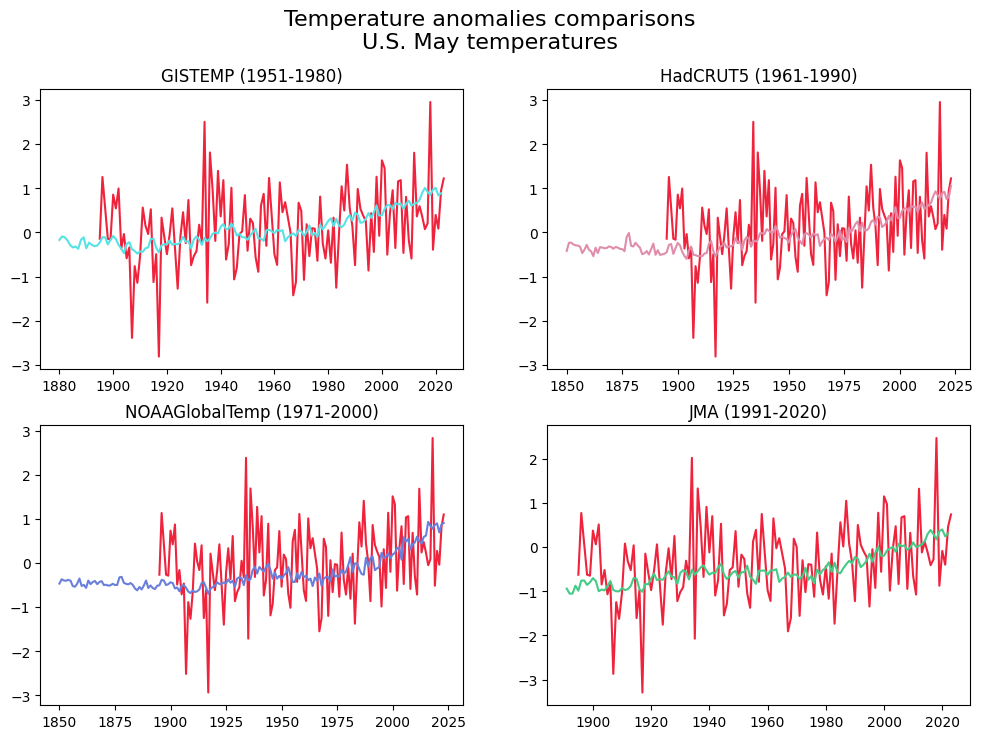

```python
fig, ((ax1, ax2), (ax3, ax4)) = plt.subplots(2, 2, figsize=(12, 8))
fig.suptitle(f"Temperature anomalies comparisons\nU.S. May temperatures",
             fontsize=16)
# U.S. temperatures
names = ['HadCRUT5', 'GISTEMP', 'NOAAGlobalTemp', 'JMA']
axes = [ax1, ax2, ax3, ax4]
US = "#EF233C"
for i in range(4):
    axes[i].plot(df_compar["Year"], df_compar[names[i]], color=US)

# GISTEMP
ax1.plot(df_gistemp["Year"], df_gistemp["Glob"], color="#57E2E5")
ax1.set_title("GISTEMP (1951-1980)")
# HadCRUT5
ax2.plot(df_crut5["Time"], df_crut5["Anomaly (deg C)"], color="#E08DAC")
ax2.set_title("HadCRUT5 (1961-1990)")
# NOAAGlobalTemp
ax3.plot(df_noaa["Year"], df_noaa["Value"], color="#6A7FDB")
ax3.set_title("NOAAGlobalTemp (1971-2000)")
# JMA
ax4.plot(df_jma["Year"], df_jma["Value"], color="#45CB85")
ax4.set_title("JMA (1991-2020)")

plt.show()
```

Larger temperature anomalies are observed with the U.S. dataset, although it seems to evolve in the same way. This can be explained by the way temperatures were measured. Here, the temperature measured is that of the atmosphere, whereas the other datasets measure both land and sea surface.

To compare their evolution, we can use a rolling mean to smooth the U.S. data. We have arbitrarily chosen to average over 20 years, which visually yields a good fit.

```python
df_compar_smooth = pd.DataFrame(df_compar["Year"])
smoothing = 20
for name in names:
    df_compar_smooth[name] = df_compar[name].rolling(smoothing,
                                                     center=True).mean()
df_compar_smooth.head(15)
```

|  | Year | HadCRUT5 | GISTEMP | NOAAGlobalTemp | JMA |
| --- | --- | --- | --- | --- | --- |
| 0 | 1895 | NaN | NaN | NaN | NaN |
| 1 | 1896 | NaN | NaN | NaN | NaN |
| 2 | 1897 | NaN | NaN | NaN | NaN |
| 3 | 1898 | NaN | NaN | NaN | NaN |
| 4 | 1899 | NaN | NaN | NaN | NaN |
| 5 | 1900 | NaN | NaN | NaN | NaN |
| 6 | 1901 | NaN | NaN | NaN | NaN |
| 7 | 1902 | NaN | NaN | NaN | NaN |
| 8 | 1903 | NaN | NaN | NaN | NaN |
| 9 | 1904 | NaN | NaN | NaN | NaN |
| 10 | 1905 | -0.059907 | -0.058981 | -0.181204 | -0.540463 |
| 11 | 1906 | -0.109074 | -0.108148 | -0.230370 | -0.589630 |
| 12 | 1907 | -0.196574 | -0.195648 | -0.317870 | -0.677130 |
| 13 | 1908 | -0.364630 | -0.363704 | -0.485926 | -0.845185 |
| 14 | 1909 | -0.340741 | -0.339815 | -0.462037 | -0.821296 |

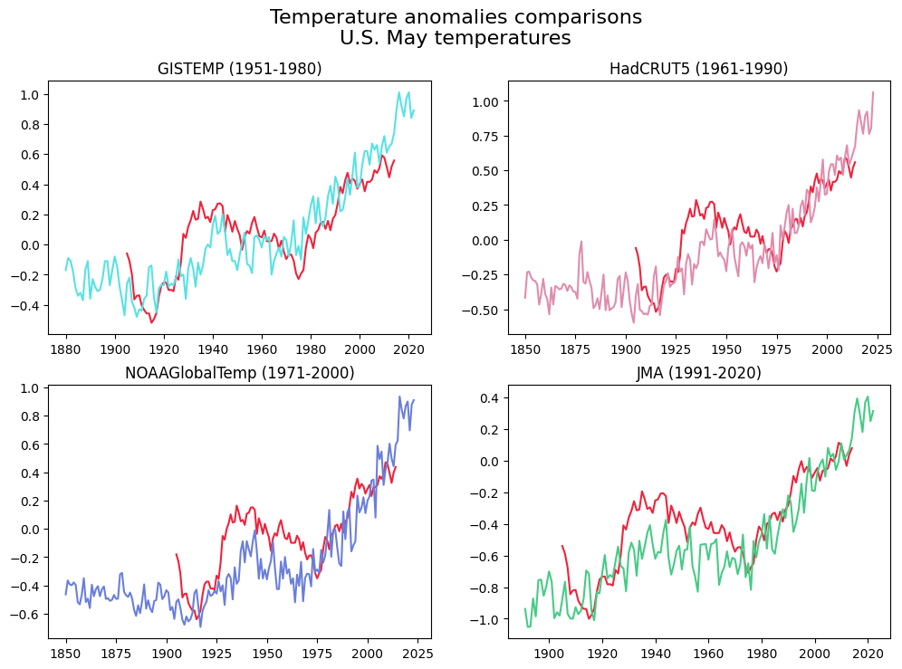

```python
fig, ((ax1, ax2), (ax3, ax4)) = plt.subplots(2, 2, figsize=(12, 8))
fig.suptitle(f"Temperature anomalies comparisons\nU.S. May temperatures",
             fontsize=16)
# U.S. temperatures
axes = [ax1, ax2, ax3, ax4]
for i in range(4):
    axes[i].plot(df_compar_smooth["Year"],
                 df_compar_smooth[names[i]], color=US)

# GISTEMP
ax1.plot(df_gistemp["Year"], df_gistemp["Glob"], color="#57E2E5")
ax1.set_title("GISTEMP (1951-1980)")
# HadCRUT5
ax2.plot(df_crut5["Time"], df_crut5["Anomaly (deg C)"], color="#E08DAC")
ax2.set_title("HadCRUT5 (1961-1990)")
# NOAAGlobalTemp
ax3.plot(df_noaa["Year"], df_noaa["Value"], color="#6A7FDB")
ax3.set_title("NOAAGlobalTemp (1971-2000)")
# JMA
ax4.plot(df_jma["Year"], df_jma["Value"], color="#45CB85")
ax4.set_title("JMA (1991-2020)")

plt.show()
```

Thus, we can confirm that the four datasets accurately compute temperature anomalies. In spite of baselines being different, all datasets show the same temperature trend.